# How to predict antimicrobial resistance

Matthijs S. Berends

28 May 2020

## Needed R packages

As with many uses in R, we need some additional packages for AMR analysis. Our package works closely together with the [tidyverse packages](https://www.tidyverse.org) [`dplyr`](https://dplyr.tidyverse.org/) and [`ggplot2`](https://ggplot2.tidyverse.org) by Dr Hadley Wickham. The tidyverse tremendously improves the way we conduct data science - it allows for a very natural way of writing syntaxes and creating beautiful plots in R.

Our `AMR` package depends on these packages and even extends their use and functions.

```r
library(dplyr)
library(ggplot2)
library(AMR)

# (if not yet installed, install with:)
# install.packages(c("tidyverse", "AMR"))
```

## Prediction analysis

Our package contains a function `resistance_predict()`, which takes the same input as functions for other AMR analysis. Based on a date column, it calculates cases per year and uses a regression model to predict antimicrobial resistance.

It is basically as easy as:

```r
# resistance prediction of piperacillin/tazobactam (TZP):
resistance_predict(tbl = example_isolates, col_date = "date", col_ab = "TZP", model = "binomial")

# or:
example_isolates %>%
  resistance_predict(col_ab = "TZP",
                     model  "binomial")

# to bind it to object 'predict_TZP' for example:
predict_TZP <- example_isolates %>%
  resistance_predict(col_ab = "TZP",
                     model = "binomial")
```

The function will look for a date column itself if `col_date` is not set.

When running any of these commands, a summary of the regression model will be printed unless using `resistance_predict(..., info = FALSE)`.

```
# NOTE: Using column `date` as input for `col_date`.
```

This text is only a printed summary - the actual result (output) of the function is a `data.frame` containing for each year: the number of observations, the actual observed resistance, the estimated resistance and the standard error below and above the estimation:

```r
predict_TZP
#    year      value    se_min    se_max observations   observed  estimated
# 1  2002 0.20000000        NA        NA           15 0.20000000 0.05616378
# 2  2003 0.06250000        NA        NA           32 0.06250000 0.06163839
# 3  2004 0.08536585        NA        NA           82 0.08536585 0.06760841
# 4  2005 0.05000000        NA        NA           60 0.05000000 0.07411100
# 5  2006 0.05084746        NA        NA           59 0.05084746 0.08118454
# 6  2007 0.12121212        NA        NA           66 0.12121212 0.08886843
# 7  2008 0.04166667        NA        NA           72 0.04166667 0.09720264
# 8  2009 0.01639344        NA        NA           61 0.01639344 0.10622731
# 9  2010 0.05660377        NA        NA           53 0.05660377 0.11598223
# 10 2011 0.18279570        NA        NA           93 0.18279570 0.12650615
# 11 2012 0.30769231        NA        NA           65 0.30769231 0.13783610
# 12 2013 0.06896552        NA        NA           58 0.06896552 0.15000651
# 13 2014 0.10000000        NA        NA           60 0.10000000 0.16304829
# 14 2015 0.23636364        NA        NA           55 0.23636364 0.17698785
# 15 2016 0.22619048        NA        NA           84 0.22619048 0.19184597
# 16 2017 0.16279070        NA        NA           86 0.16279070 0.20763675
# 17 2018 0.22436641 0.1938710 0.2548618           NA         NA 0.22436641
# 18 2019 0.24203228 0.2062911 0.2777735           NA         NA 0.24203228
# 19 2020 0.26062172 0.2191758 0.3020676           NA         NA 0.26062172
# 20 2021 0.28011130 0.2325557 0.3276669           NA         NA 0.28011130
# 21 2022 0.30046606 0.2464567 0.3544755           NA         NA 0.30046606
# 22 2023 0.32163907 0.2609011 0.3823771           NA         NA 0.32163907
# 23 2024 0.34357130 0.2759081 0.4112345           NA         NA 0.34357130
# 24 2025 0.36619175 0.2914934 0.4408901           NA         NA 0.36619175
# 25 2026 0.38941799 0.3076686 0.4711674           NA         NA 0.38941799
# 26 2027 0.41315710 0.3244399 0.5018743           NA         NA 0.41315710
# 27 2028 0.43730688 0.3418075 0.5328063           NA         NA 0.43730688
# 28 2029 0.46175755 0.3597639 0.5637512           NA         NA 0.46175755
# 29 2030 0.48639359 0.3782932 0.5944939           NA         NA 0.48639359
```

The function `plot` is available in base R, and can be extended by other packages to depend the output based on the type of input. We extended its function to cope with resistance predictions:

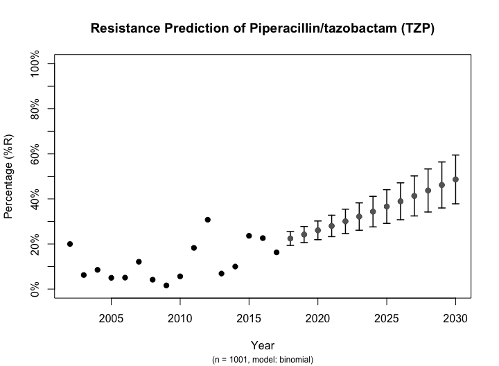

```r
plot(predict_TZP)
```

This is the fastest way to plot the result. It automatically adds the right axes, error bars, titles, number of available observations and type of model.

We also support the `ggplot2` package with our custom function `ggplot_rsi_predict()` to create more appealing plots:

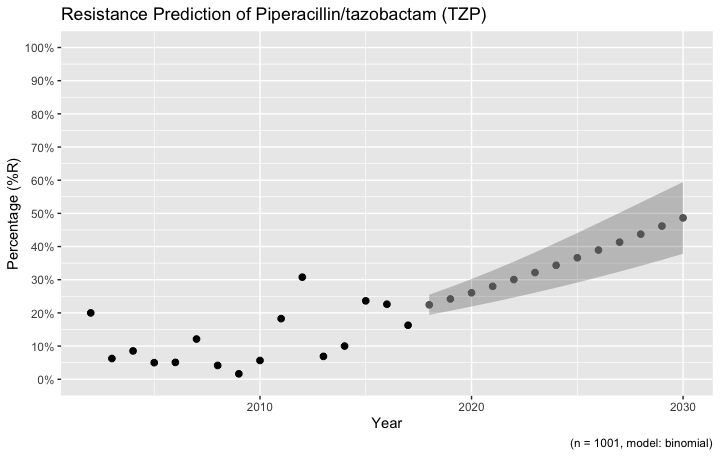

```r
ggplot_rsi_predict(predict_TZP)
```

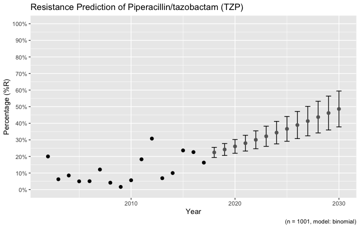

```r
# choose for error bars instead of a ribbon
ggplot_rsi_predict(predict_TZP, ribbon = FALSE)
```

### Choosing the right model

Resistance is not easily predicted; if we look at vancomycin resistance in Gram-positive bacteria, the spread (i.e. standard error) is enormous:

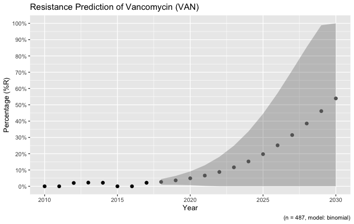

```r
example_isolates %>%
  filter(mo_gramstain(mo, language = NULL) == "Gram-positive") %>%
  resistance_predict(col_ab = "VAN", year_min = 2010, info = FALSE, model = "binomial") %>%
  ggplot_rsi_predict()
# NOTE: Using column `date` as input for `col_date`.
```

Vancomycin resistance could be 100% in ten years, but might also stay around 0%.

You can define the model with the `model` parameter. The model chosen above is a generalised linear regression model using a binomial distribution, assuming that a period of zero resistance was followed by a period of increasing resistance leading slowly to more and more resistance.

Valid values are:

| Input values | Function used by R | Type of model |
| --- | --- | --- |
| `"binomial"` or `"binom"` or `"logit"` | `glm(..., family = binomial)` | Generalised linear model with binomial distribution |
| `"loglin"` or `"poisson"` | `glm(..., family = poisson)` | Generalised linear model with poisson distribution |
| `"lin"` or `"linear"` | `lm()` | Linear model |

For the vancomycin resistance in Gram-positive bacteria, a linear model might be more appropriate since no binomial distribution is to be expected based on the observed years:

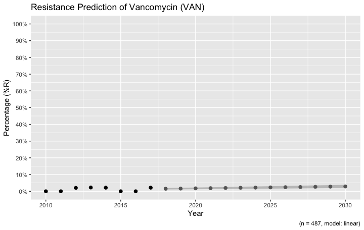

```r
example_isolates %>%
  filter(mo_gramstain(mo, language = NULL) == "Gram-positive") %>%
  resistance_predict(col_ab = "VAN", year_min = 2010, info = FALSE, model = "linear") %>%
  ggplot_rsi_predict()
# NOTE: Using column `date` as input for `col_date`.
```

This seems more likely, doesn’t it?

The model itself is also available from the object, as an `attribute`:

```r
model <- attributes(predict_TZP)$model

summary(model)$family
#
# Family: binomial
# Link function: logit

summary(model)$coefficients
#                  Estimate  Std. Error   z value     Pr(>|z|)
# (Intercept) -200.67944891 46.17315349 -4.346237 1.384932e-05
# year           0.09883005  0.02295317  4.305725 1.664395e-05
```